# NEP analysis

JMH

11/13/2020

# Analysis of ER response to N and P enrichment

## Libraries

```r
library(tidyverse)
library(gamm4)
library(mgcViz)
library(MuMIn)
library(forecast)
library(gridExtra)
library(tidymv)
```

## Load & munge data

Loads data, calculates log GPP and ER, does a ridiculous transformation of NEP, and centers stream water temp at 10C as inverse kT

```r
met2 <- read.csv("00_metab_for_Hoodie.csv") %>%
  mutate(Pdt = as.POSIXct(Pdt, format = "%m/%d/%y"),
         doy = as.numeric(strftime(Pdt, format = "%j")),
         Y = as.numeric(strftime(Pdt, format = "%Y")),
         Yf = as.factor(as.character(Y)),
         lGPP = log(GPP_median),
         lER = log(-ER_median),
         #centering
         invKT.C = one_over_kT - 1/((10 + 273.15)*0.0000862),
         streamTreat = as.factor(paste0(stream,"_",treatment))) %>%
  mutate_at(vars(stream, treatment), funs(as.factor(.))) %>%
  rename(invKT = one_over_kT)
```

For predictor variables, we want to center Temp, light, Q, and GPP. We’ll do that using stream means, which we calculate below

```r
# stream mean
metS <- met2 %>%
  group_by(stream, treatment) %>%
  summarise_at(vars(meanTemp, invKT.C, meanQds, LightPerDay, lGPP), funs(mean(., na.rm = TRUE))) %>%
  group_by(stream) %>%
  summarise_at(vars(meanTemp, invKT.C, meanQds, LightPerDay, lGPP), funs(mean(., na.rm = TRUE))) %>%
  rename_at(vars(-stream), function(x) paste0(x,".StMean"))

# global mean
metG0 <- met2 %>%
  group_by(stream, treatment) %>%
  summarise_at(vars(meanTemp, invKT.C, meanQds, LightPerDay, lGPP), funs(mean(., na.rm = TRUE))) %>%
  group_by(stream) %>%
  summarise_at(vars(meanTemp, invKT.C, meanQds, LightPerDay, lGPP), funs(mean(., na.rm = TRUE))) %>%
  group_by() %>%
  summarise_at(vars(meanTemp, invKT.C, meanQds, LightPerDay, lGPP), funs(mean(., na.rm = TRUE)))%>%
  rename_at(vars(meanTemp:lGPP), function(x) paste0(x,".GMean"))

metG <- rbind(metG0, metG0, metG0, metG0)
metG$stream <- c("st11U", "st18", "st6", "st9")
```

Now, we log transform Q, GPP, and light then center on mean logged value (you can’t center then log).

```r
met <- met2 %>%
  full_join(metS, by = "stream") %>%
  full_join(metG, by = "stream") %>%
  #these are centered on the stream mean
  mutate(Tanom.iktCs = invKT.C - invKT.C.StMean,
         Tanom.iktCg = invKT.C - invKT.C.GMean,
         Tanom.Cs = meanTemp - meanTemp.StMean,
         Tanom.Cg = meanTemp - meanTemp.GMean,
         LightPerDayCs = LightPerDay - LightPerDay.StMean,
         LightPerDayCg = LightPerDay - LightPerDay.GMean,
         meanQdsCs = meanQds - meanQds.StMean,
         meanQdsCg = meanQds - meanQds.GMean,
         LightPerDay.l = log(LightPerDay),
         meanQds.l = log(meanQds),
         LightPerDay.lcs = LightPerDay.l - log(LightPerDay.StMean),
         LightPerDay.lcg = LightPerDay.l - log(LightPerDay.GMean),
         meanQds.lcs = meanQds.l - log(meanQds.StMean),
         meanQds.lcg = meanQds.l - log(meanQds.GMean),
         lGPP.cs = lGPP - lGPP.StMean,
         lGPP.cg = lGPP - lGPP.GMean,
         streamTreat = paste0(stream," ", treatment),
         stream = as.factor(stream))
```

## Quick visualization

### NEP

Focus on NEP response.

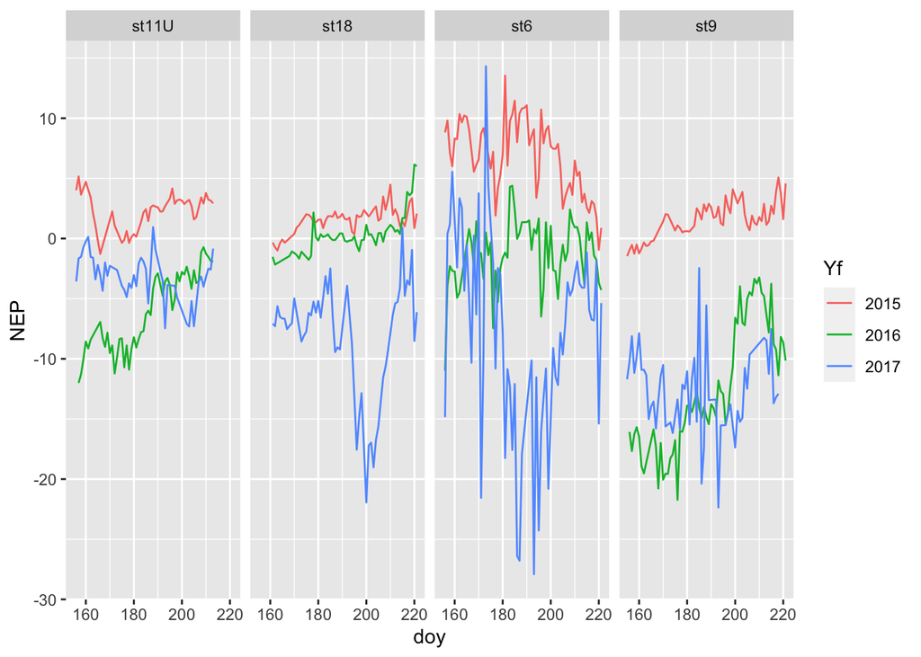

Access normality: NEP - not terrible giving weird residuals, not sure what I can do

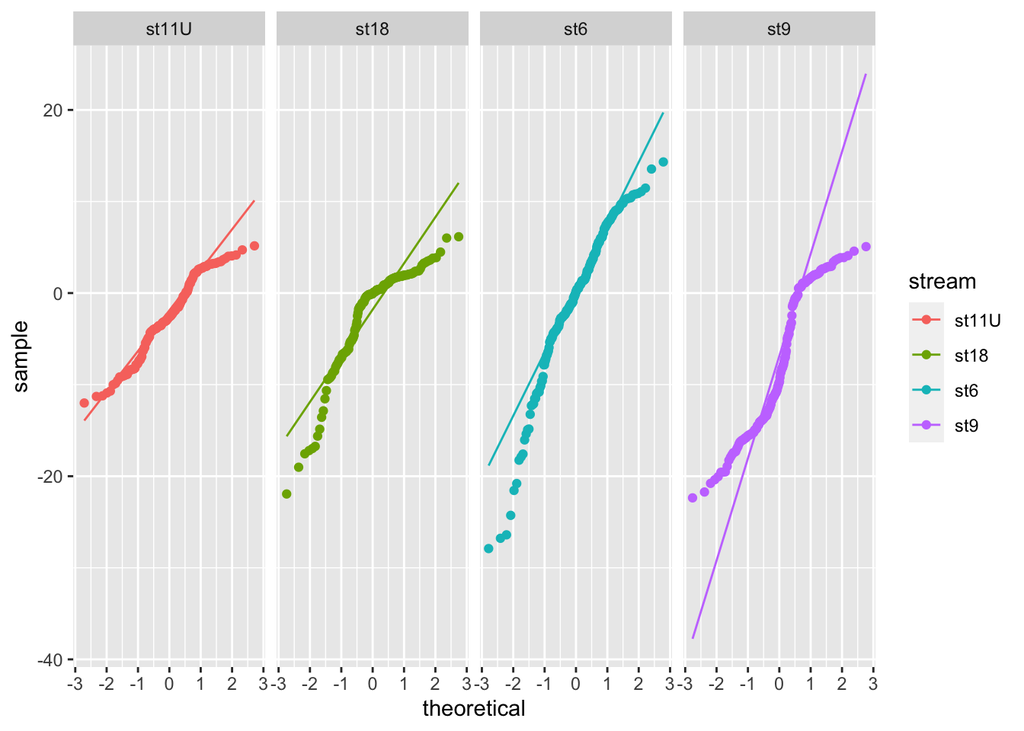

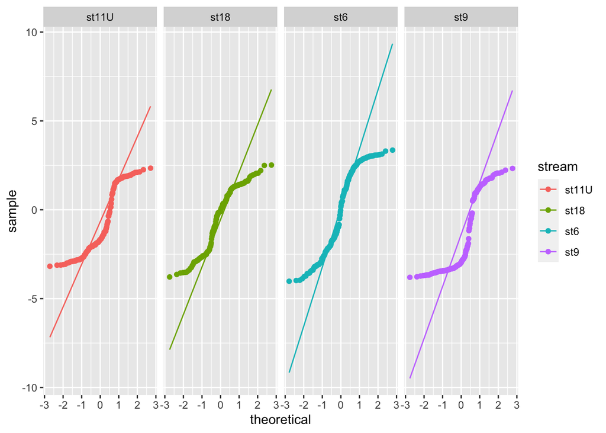

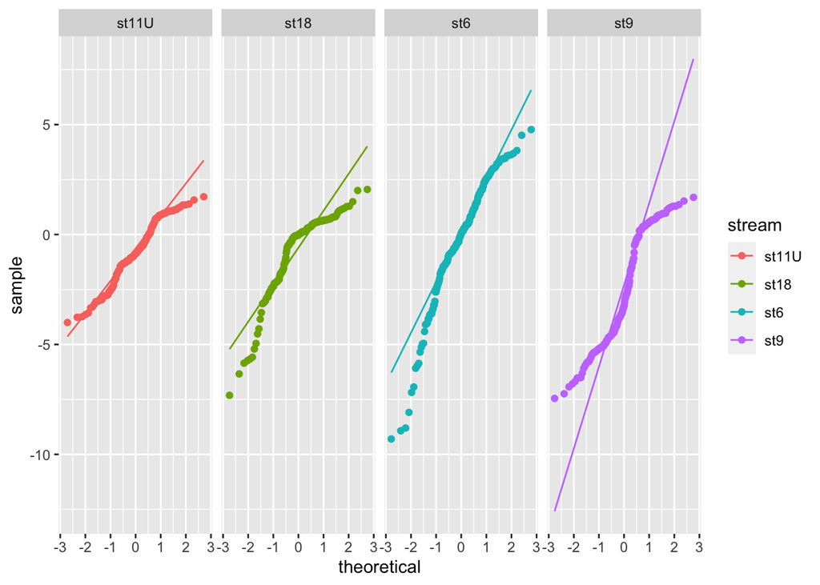

```r
ggplot(met, aes(sample = NEP^1/3, color = stream)) +stat_qq() + stat_qq_line() +
  facet_grid(.~stream)
```

```r
library(car)
```

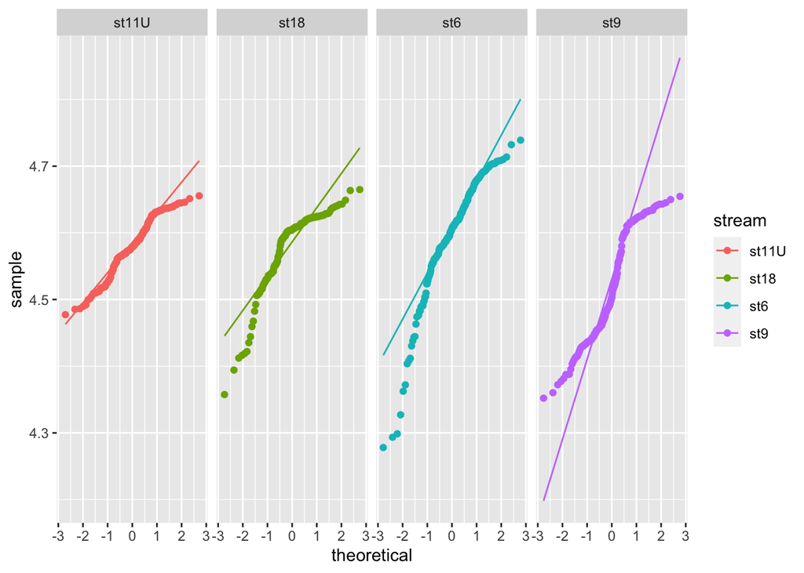

```r
ggplot(met, aes(sample = log(NEP+100), color = stream)) +stat_qq() + stat_qq_line() +
  facet_grid(.~stream)
```

# NEP models

Likely maximal models model with light won’t converge with a ‘by = stream’

```r
g.nep.PutGLOB0s <- gamm(NEP ~ treatment*invKT.C.StMean +  s(meanQds.lcs, by = stream) , REML = FALSE, data = met)
g.nep.PutGLOB1s <- gamm(NEP ~ treatment*invKT.C.StMean +  s(meanQds.lcs, by = stream) +
                     s(LightPerDay.lcg), REML = FALSE, data = met)
```

Light model is massively better

```r
model.sel(g.nep.PutGLOB0s$lme, g.nep.PutGLOB1s$lme)
```

```
## Model selection table
##                     X             family
## g.nep.PutGLOB1s$lme + gaussian(identity)
## g.nep.PutGLOB0s$lme + gaussian(identity)
##                                                                                                      random
## g.nep.PutGLOB1s$lme X-g+X.0-g.0%i%g+X.1-g.1%i%g.0%i%g+X.2-g.2%i%g.1%i%g.0%i%g+X.3-g.3%i%g.2%i%g.1%i%g.0%i%g
## g.nep.PutGLOB0s$lme                               X-g+X.0-g.0%i%g+X.1-g.1%i%g.0%i%g+X.2-g.2%i%g.1%i%g.0%i%g
##                     df    logLik   AICc  delta weight
## g.nep.PutGLOB1s$lme 17 -1903.364 3841.7   0.00      1
## g.nep.PutGLOB0s$lme 15 -2032.540 4095.8 254.15      0
## Models ranked by AICc(x)
## Random terms:
## X-g = 'Xr - 1 | g'
## X.0-g.0%i%g = 'Xr.0 - 1 | g.0 %in% g'
## X.1-g.1%i%g.0%i%g = 'Xr.1 - 1 | g.1 %in% g.0 %in% g'
## X.2-g.2%i%g.1%i%g.0%i%g = 'Xr.2 - 1 | g.2 %in% g.1 %in% g.0 %in% g'
## X.3-g.3%i%g.2%i%g.1%i%g.0%i%g = 'Xr.3 - 1 | g.3 %in% g.2 %in% g.1 %in% g.0 %in% g'
```

```r
summary(g.nep.PutGLOB1s$gam)
```

```
##
## Family: gaussian
## Link function: identity
##
## Formula:
## NEP ~ treatment * invKT.C.StMean + s(meanQds.lcs, by = stream) +
##     s(LightPerDay.lcg)
##
## Parametric coefficients:
##                                    Estimate Std. Error t value Pr(>|t|)
## (Intercept)                          2.7868     0.3207   8.690  < 2e-16 ***
## treatmentnitrogen                   -7.7677     0.4684 -16.583  < 2e-16 ***
## treatmentphosphorus                 -6.8892     0.4301 -16.017  < 2e-16 ***
## invKT.C.StMean                      -7.0955     0.7971  -8.902  < 2e-16 ***
## treatmentnitrogen:invKT.C.StMean    11.1537     1.1761   9.484  < 2e-16 ***
## treatmentphosphorus:invKT.C.StMean   5.0679     1.1204   4.523 7.24e-06 ***
## ---
## Signif. codes:  0 '***' 0.001 '**' 0.01 '*' 0.05 '.' 0.1 ' ' 1
##
## Approximate significance of smooth terms:
##                              edf Ref.df      F  p-value
## s(meanQds.lcs):streamst11U 1.000  1.000  7.529  0.00624 **
## s(meanQds.lcs):streamst18  4.207  4.207 12.682 2.75e-10 ***
## s(meanQds.lcs):streamst6   3.074  3.074  4.873  0.00194 **
## s(meanQds.lcs):streamst9   8.964  8.964 46.773  < 2e-16 ***
## s(LightPerDay.lcg)         2.668  2.668 33.242  < 2e-16 ***
## ---
## Signif. codes:  0 '***' 0.001 '**' 0.01 '*' 0.05 '.' 0.1 ' ' 1
##
## R-sq.(adj) =  0.722
##   Scale est. = 14.069    n = 677
```

```r
g.nep.PutGLOB1s.b <- getViz(g.nep.PutGLOB1s$gam)
```

Bit funky around zero good

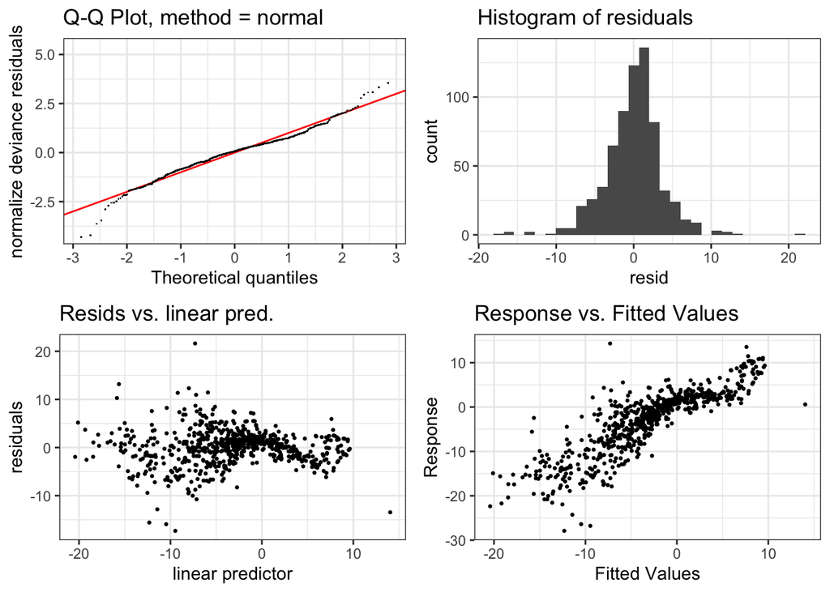

```r
check(g.nep.PutGLOB1s.b)
```

So autocorrelation

```r
# https://www.kaggle.com/timib1203/managing-many-models-with-tidyr-purrr-and-broom
met.PutGLOB <- met %>%
  mutate(g.nepRes = resid(g.nep.PutGLOB1s$lme, type = "normalized")) %>%
  select(streamTreat, g.nepRes) %>%
  group_by(streamTreat) %>%
  nest() %>%
  mutate(acf = map(.x = data, .f = function(d) ggAcf(d$g.nepRes) + labs(title = streamTreat)))
```

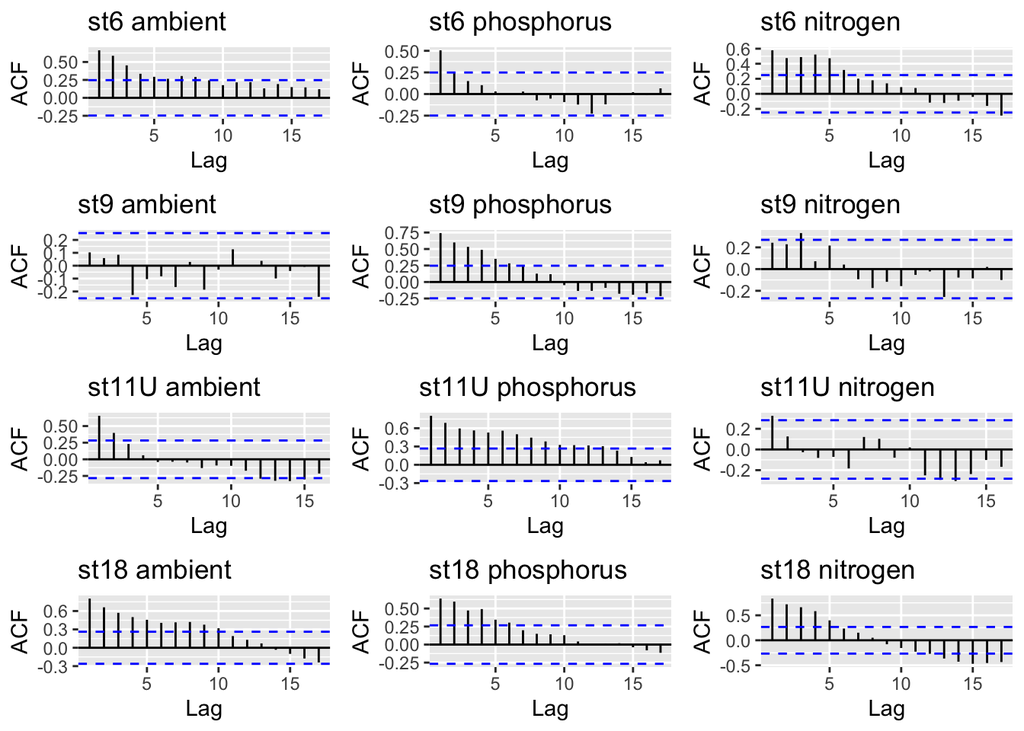

```r
grid.arrange(grobs = met.PutGLOB$acf, ncol = 3)
```

Evaluate different corr structures

```r
g.nep.AC_1.0 <- gamm(NEP ~ treatment*invKT.C.StMean +  s(meanQds.lcs, by = stream) +
                     s(LightPerDay.lcg),
                correlation = corARMA(p = 1,q = 0, form = ~ doy | streamTreat), REML = FALSE, data = met)

g.nep.AC_1.1 <- gamm(NEP ~ treatment*invKT.C.StMean +  s(meanQds.lcs, by = stream) +
                      s(LightPerDay.lcg),
                correlation = corARMA(p = 1,q = 1, form = ~ doy | streamTreat), REML = FALSE, data = met)

g.nep.AC_1.2 <- gamm(NEP ~ treatment*invKT.C.StMean +  s(meanQds.lcs, by = stream) +
                      s(LightPerDay.lcg),
                correlation = corARMA(p = 1,q = 2, form = ~ doy | streamTreat), REML = FALSE, data = met)

g.nep.AC_2.0 <- gamm(NEP ~ treatment*invKT.C.StMean +  s(meanQds.lcs, by = stream) +
                      s(LightPerDay.lcg),
                correlation = corARMA(p = 2,q = 0, form = ~ doy | streamTreat), REML = FALSE, data = met)


g.nep.AC_2.1 <- gamm(NEP ~ treatment*invKT.C.StMean +  s(meanQds.lcs, by = stream) +
                      s(LightPerDay.lcg),
                correlation = corARMA(p = 2,q = 1, form = ~ doy | streamTreat), REML = FALSE, data = met)

g.nep.AC_2.2 <- gamm(NEP ~ treatment*invKT.C.StMean +  s(meanQds.lcs, by = stream) +
                      s(LightPerDay.lcg),
                correlation = corARMA(p = 2,q = 2, form = ~ doy | streamTreat), REML = FALSE, data = met)

g.nep.AC_3.0 <- gamm(NEP ~ treatment*invKT.C.StMean +  s(meanQds.lcs, by = stream) +
                      s(LightPerDay.lcg),
                correlation = corARMA(p = 3,q = 0, form = ~ doy | streamTreat), REML = FALSE, data = met)

g.nep.AC_3.1 <- gamm(NEP ~ treatment*invKT.C.StMean +  s(meanQds.lcs, by = stream) +
                      s(LightPerDay.lcg),
                correlation = corARMA(p = 3,q = 1, form = ~ doy | streamTreat), REML = FALSE, data = met)
#
g.nep.AC_3.2 <- gamm(NEP ~ treatment*invKT.C.StMean +  s(meanQds.lcs, by = stream) +
                      s(LightPerDay.lcg),
                correlation = corARMA(p = 3,q = 2, form = ~ doy | streamTreat), REML = FALSE, data = met)
```

Model selection pretty much all equally good, will use the same as gpp

```r
model.sel(g.nep.AC_1.0$lme, g.nep.AC_1.1$lme, g.nep.AC_1.2$lme, g.nep.AC_2.0$lme,
          g.nep.AC_2.1$lme, g.nep.AC_2.2$lme, g.nep.AC_3.0$lme, g.nep.AC_3.1$lme, g.nep.AC_3.2$lme)
```

```
## Model selection table
##                  X             family df    logLik   AICc delta weight
## g.nep.AC_3.0$lme + gaussian(identity) 20 -1557.961 3157.2  0.00  0.244
## g.nep.AC_1.1$lme + gaussian(identity) 19 -1559.281 3157.7  0.52  0.189
## g.nep.AC_2.2$lme + gaussian(identity) 21 -1557.400 3158.2  1.01  0.148
## g.nep.AC_3.1$lme + gaussian(identity) 21 -1557.411 3158.2  1.03  0.146
## g.nep.AC_3.2$lme + gaussian(identity) 22 -1556.416 3158.4  1.18  0.136
## g.nep.AC_1.2$lme + gaussian(identity) 20 -1559.220 3159.7  2.52  0.069
## g.nep.AC_2.1$lme + gaussian(identity) 20 -1559.237 3159.8  2.55  0.068
## g.nep.AC_2.0$lme + gaussian(identity) 19 -1573.450 3186.1 28.85  0.000
## g.nep.AC_1.0$lme + gaussian(identity) 18 -1606.759 3250.6 93.35  0.000
## Models ranked by AICc(x)
## Random terms (all models):
## 'Xr - 1 | g', 'Xr.0 - 1 | g.0 %in% g', 'Xr.1 - 1 | g.1 %in% g.0 %in% g', 'Xr.2 - 1 | g.2 %in% g.1 %in% g.0 %in% g', 'Xr.3 - 1 | g.3 %in% g.2 %in% g.1 %in% g.0 %in% g'
```

Not looking so good. I tried a bunch of these and none improved things.

```r
# https://www.kaggle.com/timib1203/managing-many-models-with-tidyr-purrr-and-broom
# https://jroy042.github.io/nonlinear/week4.html
# https://stackoverflow.com/questions/47586110/autocorrelation-in-generalized-additive-models-gam
g.nep.AC_best.acf <- met %>%
  mutate(g.nepRes = resid(g.nep.AC_2.2$lme, type = "normalized")) %>%
  select(streamTreat, g.nepRes) %>%
  group_by(streamTreat) %>%
  nest() %>%
  mutate(acf = map(.x = data, .f = function(d) ggAcf(d$g.nepRes) + labs(title = streamTreat)))
```

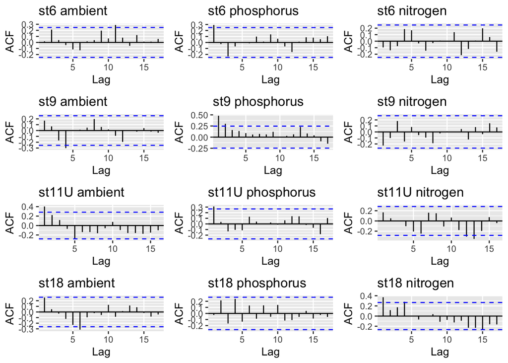

```r
grid.arrange(grobs = g.nep.AC_best.acf$acf, ncol = 3)
```

```r
BestNEPCor <- corARMA(p = 2,q = 2, form = ~ doy | streamTreat)
```

```r
# STREAM CENTgppED Q
g.nep.NutXTs <- gamm(NEP ~ treatment*invKT.C.StMean +  s(meanQds.lcs, by = stream)+
                      s(LightPerDay.lcg),
                correlation = BestNEPCor, REML = FALSE, data = met)

g.nep.NutpTs <- gamm(NEP ~ treatment + invKT.C.StMean +  s(meanQds.lcs, by = stream)+
                      s(LightPerDay.lcg),
                correlation = BestNEPCor, REML = FALSE, data = met)

g.nep.NutXsts <- gamm(NEP ~ treatment*stream +  s(meanQds.lcs, by = stream)+
                      s(LightPerDay.lcg),
                correlation = BestNEPCor, REML = FALSE, data = met)

g.nep.Nutpsts <- gamm(NEP ~ treatment + stream +  s(meanQds.lcs, by = stream)+
                      s(LightPerDay.lcg),
                correlation = BestNEPCor, REML = FALSE, data = met)

g.nep.Nuts <- gamm(NEP ~ treatment +  s(meanQds.lcs, by = stream)+
                      s(LightPerDay.lcg),
                correlation = BestNEPCor, REML = FALSE, data = met)

g.nep.Ts <- gamm(NEP ~ invKT.C.StMean +  s(meanQds.lcs, by = stream)+
                      s(LightPerDay.lcg),
                correlation = BestNEPCor, REML = FALSE, data = met)

g.nep.sts <- gamm(NEP ~ stream +  s(meanQds.lcs, by = stream)+
                      s(LightPerDay.lcg),
                correlation = BestNEPCor, REML = FALSE, data = met)

g.nep.nulls <- gamm(NEP ~ s(meanQds.lcs, by = stream)+
                      s(LightPerDay.lcg),
                correlation = BestNEPCor, REML = FALSE, data = met)

g.nep.nullsnoL <- gamm(NEP ~ s(meanQds.lcs, by = stream),
                correlation = BestNEPCor, REML = FALSE, data = met)

g.nep.nullnoQs <- gamm(NEP ~ s(LightPerDay.lcg),
                correlation = BestNEPCor, REML = FALSE, data = met)
```

The best model is Nut X stream Temp comes in at delAIC of ~8 Nut +T

```r
model.sel(g.nep.NutXTs$lme, g.nep.NutpTs$lme, g.nep.NutXsts$lme, g.nep.Nutpsts$lme, g.nep.Nuts$lme, g.nep.Ts$lme, g.nep.sts$lme, g.nep.nulls$lme,
          g.nep.nullsnoL$lme, g.nep.nullnoQs$lme)
```

```
## Model selection table
##                    X             family
## g.nep.NutXsts$lme  + gaussian(identity)
## g.nep.Nutpsts$lme  + gaussian(identity)
## g.nep.Nuts$lme     + gaussian(identity)
## g.nep.NutpTs$lme   + gaussian(identity)
## g.nep.NutXTs$lme   + gaussian(identity)
## g.nep.nulls$lme    + gaussian(identity)
## g.nep.Ts$lme       + gaussian(identity)
## g.nep.sts$lme      + gaussian(identity)
## g.nep.nullnoQs$lme + gaussian(identity)
## g.nep.nullsnoL$lme + gaussian(identity)
##                                                                                                     random
## g.nep.NutXsts$lme  X-g+X.0-g.0%i%g+X.1-g.1%i%g.0%i%g+X.2-g.2%i%g.1%i%g.0%i%g+X.3-g.3%i%g.2%i%g.1%i%g.0%i%g
## g.nep.Nutpsts$lme  X-g+X.0-g.0%i%g+X.1-g.1%i%g.0%i%g+X.2-g.2%i%g.1%i%g.0%i%g+X.3-g.3%i%g.2%i%g.1%i%g.0%i%g
## g.nep.Nuts$lme     X-g+X.0-g.0%i%g+X.1-g.1%i%g.0%i%g+X.2-g.2%i%g.1%i%g.0%i%g+X.3-g.3%i%g.2%i%g.1%i%g.0%i%g
## g.nep.NutpTs$lme   X-g+X.0-g.0%i%g+X.1-g.1%i%g.0%i%g+X.2-g.2%i%g.1%i%g.0%i%g+X.3-g.3%i%g.2%i%g.1%i%g.0%i%g
## g.nep.NutXTs$lme   X-g+X.0-g.0%i%g+X.1-g.1%i%g.0%i%g+X.2-g.2%i%g.1%i%g.0%i%g+X.3-g.3%i%g.2%i%g.1%i%g.0%i%g
## g.nep.nulls$lme    X-g+X.0-g.0%i%g+X.1-g.1%i%g.0%i%g+X.2-g.2%i%g.1%i%g.0%i%g+X.3-g.3%i%g.2%i%g.1%i%g.0%i%g
## g.nep.Ts$lme       X-g+X.0-g.0%i%g+X.1-g.1%i%g.0%i%g+X.2-g.2%i%g.1%i%g.0%i%g+X.3-g.3%i%g.2%i%g.1%i%g.0%i%g
## g.nep.sts$lme      X-g+X.0-g.0%i%g+X.1-g.1%i%g.0%i%g+X.2-g.2%i%g.1%i%g.0%i%g+X.3-g.3%i%g.2%i%g.1%i%g.0%i%g
## g.nep.nullnoQs$lme                                                                                     X-g
## g.nep.nullsnoL$lme                               X-g+X.0-g.0%i%g+X.1-g.1%i%g.0%i%g+X.2-g.2%i%g.1%i%g.0%i%g
##                    df    logLik   AICc  delta weight
## g.nep.NutXsts$lme  27 -1545.555 3147.4   0.00  0.795
## g.nep.Nutpsts$lme  21 -1553.719 3150.8   3.41  0.144
## g.nep.Nuts$lme     18 -1558.176 3153.4   5.95  0.041
## g.nep.NutpTs$lme   19 -1558.126 3155.4   7.97  0.015
## g.nep.NutXTs$lme   21 -1557.400 3158.2  10.77  0.004
## g.nep.nulls$lme    16 -1563.840 3160.5  13.07  0.001
## g.nep.Ts$lme       17 -1563.794 3162.5  15.08  0.000
## g.nep.sts$lme      19 -1562.217 3163.6  16.15  0.000
## g.nep.nullnoQs$lme  8 -1576.784 3169.8  22.34  0.000
## g.nep.nullsnoL$lme 14 -1664.137 3356.9 209.47  0.000
## Models ranked by AICc(x)
## Random terms:
## X-g = 'Xr - 1 | g'
## X.0-g.0%i%g = 'Xr.0 - 1 | g.0 %in% g'
## X.1-g.1%i%g.0%i%g = 'Xr.1 - 1 | g.1 %in% g.0 %in% g'
## X.2-g.2%i%g.1%i%g.0%i%g = 'Xr.2 - 1 | g.2 %in% g.1 %in% g.0 %in% g'
## X.3-g.3%i%g.2%i%g.1%i%g.0%i%g = 'Xr.3 - 1 | g.3 %in% g.2 %in% g.1 %in% g.0 %in% g'
```

The best model. see above. Also looking at the nutrient + T model.

```r
g.nep.best <-  gamm(NEP ~ treatment*stream +  s(meanQds.lcs, by = stream)+
                      s(LightPerDay.lcg),
                correlation = BestNEPCor, REML = TRUE, data = met)
g.nep.bestTps <-  gamm(NEP ~ treatment + stream +  s(meanQds.lcs, by = stream)+
                      s(LightPerDay.lcg),
                correlation = BestNEPCor, REML = TRUE, data = met)
g.nep.bestTpT <-  gamm(NEP ~ treatment + invKT.C.StMean +  s(meanQds.lcs, by = stream)+
                      s(LightPerDay.lcg),
                correlation = BestNEPCor, REML = TRUE, data = met)
```

Nutrient + T model has an R2 nearly 0.3 lower! Sig effect of N and P; Temp isn’t sig.

```r
summary(g.nep.best$gam)
```

```
##
## Family: gaussian
## Link function: identity
##
## Formula:
## NEP ~ treatment * stream + s(meanQds.lcs, by = stream) + s(LightPerDay.lcg)
##
## Parametric coefficients:
##                                Estimate Std. Error t value Pr(>|t|)
## (Intercept)                      2.2300     1.7689   1.261 0.207860
## treatmentnitrogen               -5.4451     2.5361  -2.147 0.032158 *
## treatmentphosphorus             -8.6435     2.4972  -3.461 0.000572 ***
## streamst18                      -1.2842     2.4718  -0.520 0.603540
## streamst6                        4.4043     2.4399   1.805 0.071515 .
## streamst9                       -1.2699     2.4353  -0.521 0.602222
## treatmentnitrogen:streamst18    -2.9272     3.5310  -0.829 0.407414
## treatmentphosphorus:streamst18   8.5128     3.4931   2.437 0.015075 *
## treatmentnitrogen:streamst6     -8.5156     3.4831  -2.445 0.014752 *
## treatmentphosphorus:streamst6   -0.9723     3.4480  -0.282 0.778040
## treatmentnitrogen:streamst9     -7.2789     3.4961  -2.082 0.037731 *
## treatmentphosphorus:streamst9   -5.3010     3.4460  -1.538 0.124457
## ---
## Signif. codes:  0 '***' 0.001 '**' 0.01 '*' 0.05 '.' 0.1 ' ' 1
##
## Approximate significance of smooth terms:
##                              edf Ref.df      F  p-value
## s(meanQds.lcs):streamst11U 1.000  1.000  0.241    0.624
## s(meanQds.lcs):streamst18  1.000  1.000  1.237    0.267
## s(meanQds.lcs):streamst6   2.549  2.549  8.860 4.27e-05 ***
## s(meanQds.lcs):streamst9   1.000  1.000  1.705    0.192
## s(LightPerDay.lcg)         3.084  3.084 82.811  < 2e-16 ***
## ---
## Signif. codes:  0 '***' 0.001 '**' 0.01 '*' 0.05 '.' 0.1 ' ' 1
##
## R-sq.(adj) =  0.744
##   Scale est. = 12.685    n = 677
```

```r
g.nep.best.b <- getViz(g.nep.best$gam)

summary(g.nep.bestTps$gam)
```

```
##
## Family: gaussian
## Link function: identity
##
## Formula:
## NEP ~ treatment + stream + s(meanQds.lcs, by = stream) + s(LightPerDay.lcg)
##
## Parametric coefficients:
##                     Estimate Std. Error t value Pr(>|t|)
## (Intercept)           3.6833     1.9232   1.915   0.0559 .
## treatmentnitrogen   -10.0888     1.9012  -5.307 1.53e-07 ***
## treatmentphosphorus  -8.2886     1.8929  -4.379 1.39e-05 ***
## streamst18            0.6993     2.2205   0.315   0.7529
## streamst6             0.9914     2.1943   0.452   0.6516
## streamst9            -5.4907     2.1963  -2.500   0.0127 *
## ---
## Signif. codes:  0 '***' 0.001 '**' 0.01 '*' 0.05 '.' 0.1 ' ' 1
##
## Approximate significance of smooth terms:
##                              edf Ref.df      F  p-value
## s(meanQds.lcs):streamst11U 1.000  1.000  1.024    0.312
## s(meanQds.lcs):streamst18  1.000  1.000  0.917    0.339
## s(meanQds.lcs):streamst6   2.414  2.414 10.440 9.82e-06 ***
## s(meanQds.lcs):streamst9   1.000  1.000  0.986    0.321
## s(LightPerDay.lcg)         3.092  3.092 83.382  < 2e-16 ***
## ---
## Signif. codes:  0 '***' 0.001 '**' 0.01 '*' 0.05 '.' 0.1 ' ' 1
##
## R-sq.(adj) =  0.619
##   Scale est. = 19.41     n = 677
```

```r
g.nep.bestTps.b <- getViz(g.nep.bestTps$gam)

summary(g.nep.bestTpT$gam)
```

```
##
## Family: gaussian
## Link function: identity
##
## Formula:
## NEP ~ treatment + invKT.C.StMean + s(meanQds.lcs, by = stream) +
##     s(LightPerDay.lcg)
##
## Parametric coefficients:
##                     Estimate Std. Error t value Pr(>|t|)
## (Intercept)           2.8062     1.8666   1.503 0.133205
## treatmentnitrogen    -9.8879     2.5345  -3.901 0.000105 ***
## treatmentphosphorus  -8.3285     2.5278  -3.295 0.001037 **
## invKT.C.StMean        0.9879     3.1315   0.315 0.752495
## ---
## Signif. codes:  0 '***' 0.001 '**' 0.01 '*' 0.05 '.' 0.1 ' ' 1
##
## Approximate significance of smooth terms:
##                              edf Ref.df      F  p-value
## s(meanQds.lcs):streamst11U 1.000  1.000  1.071    0.301
## s(meanQds.lcs):streamst18  1.000  1.000  0.771    0.380
## s(meanQds.lcs):streamst6   2.399  2.399 10.873 6.25e-06 ***
## s(meanQds.lcs):streamst9   1.000  1.000  0.786    0.376
## s(LightPerDay.lcg)         3.092  3.092 83.593  < 2e-16 ***
## ---
## Signif. codes:  0 '***' 0.001 '**' 0.01 '*' 0.05 '.' 0.1 ' ' 1
##
## R-sq.(adj) =  0.456
##   Scale est. = 26.815    n = 677
```

```r
g.nep.bestTpT.b <- getViz(g.nep.bestTpT$gam)
```

Pretty good model

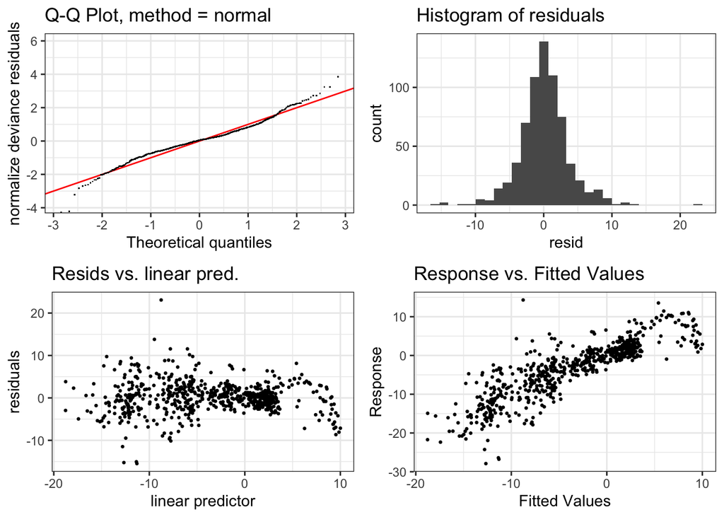

```r
check(g.nep.best.b)
```

Autocorrelation still some problems

```r
g.nep.best.acf <- met %>%
  mutate(g.nepRes = resid(g.nep.best$lme, type = "normalized")) %>%
  select(streamTreat, g.nepRes) %>%
  group_by(streamTreat) %>%
  nest() %>%
  mutate(acf = map(.x = data, .f = function(d) ggAcf(d$g.nepRes) + labs(title = streamTreat)))
```

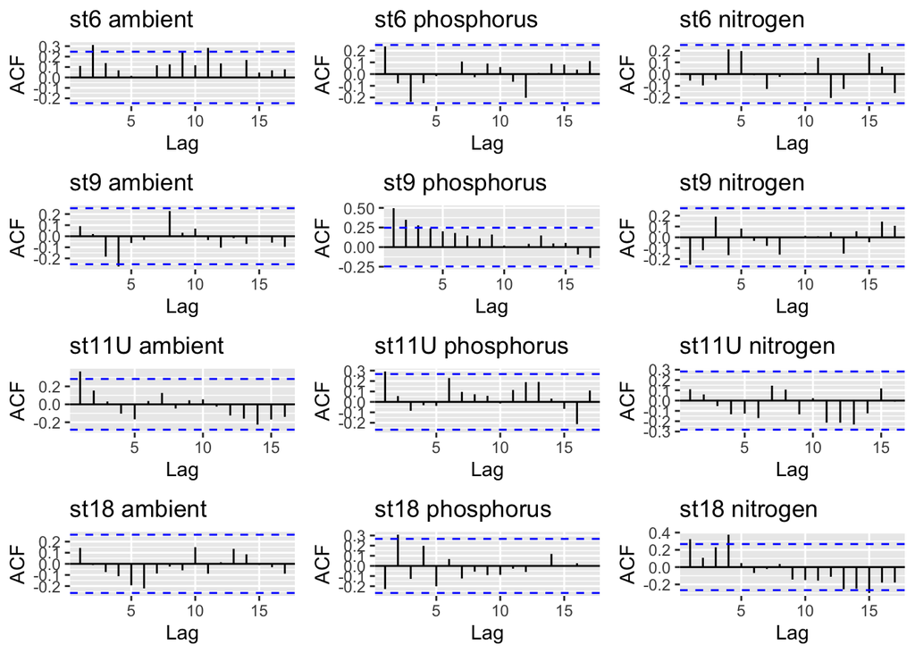

```r
grid.arrange(grobs = g.nep.best.acf$acf, ncol = 3)
```

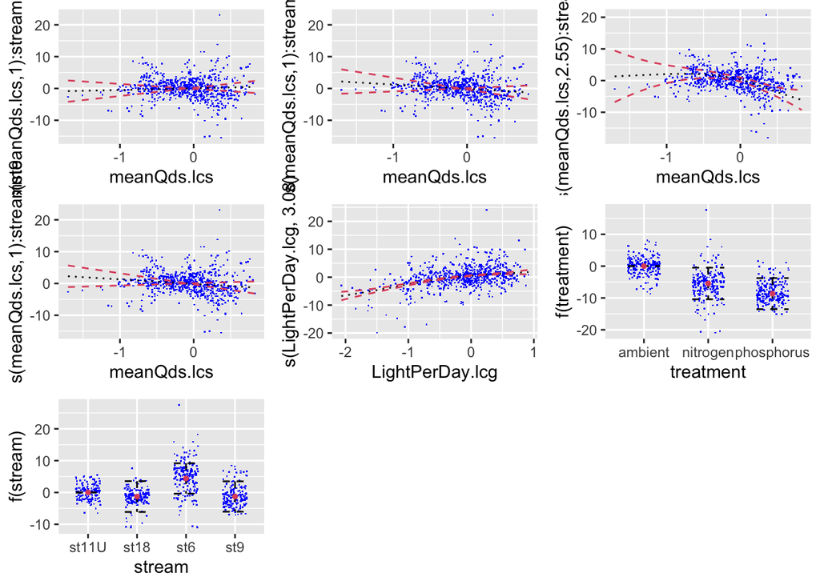

```r
NEPmod1 <- plot(g.nep.best.b, allTerms = 1) +
  l_points(color = "blue") + l_fitLine(linetype = 3) + l_fitContour() +
      l_ciLine(colour = 2) + l_ciBar() + l_fitPoints(size = 1, col = 2) + theme_get() + labs(title = NULL)

print(NEPmod1, pages = 1)
```

```r
NEPmod.pred <- predict_gam(g.nep.best$gam, exclude_terms = c("s(meanQds.lcs)", "s(LightPerDay.lcg)"),
                                          values = list(meanQds.lcs = 0, LightPerDay.lcg = 0))
```

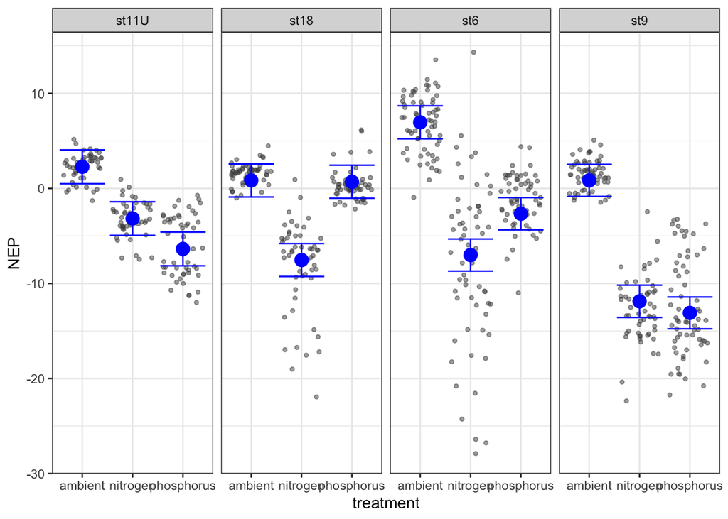

```r
NEPseAES <- aes(ymin = fit - se.fit, ymax = fit + se.fit, x = treatment)
ggplot() +
  geom_point(data = met, aes(y = NEP, x = treatment), position = "jitter", color = "grey30", size =1, alpha = 0.5) +
  geom_point(data = NEPmod.pred, aes(y = fit, x = treatment), color = "blue", size =4) +
  geom_errorbar(data = NEPmod.pred, NEPseAES, color = "blue") +
  facet_grid(. ~ stream) +
  theme_bw()
```

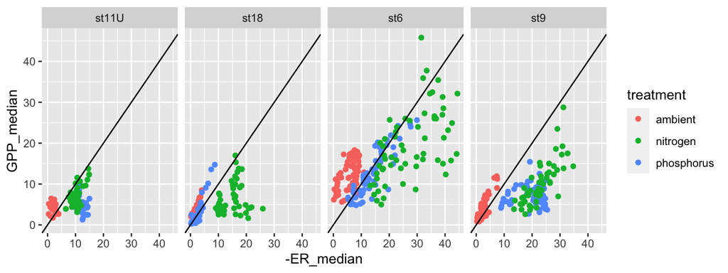

```r
ggplot(met, aes(y = GPP_median, x = -ER_median, color = treatment)) +
  geom_point() +
  facet_grid(. ~stream) +
  geom_abline(intercept =0, slope =1)
```